# Allelic covariance

## Math

Suppose that we draw two alleles from a random biallelic site, and code these as numeric by picking a random reference allele. We want to compute the covariance between these numbers. The alleles are chosen without replacement, if drawn from the same population.

First we describe how to compute the covariance of these quantities from the means and covariances *without* random choice of reference allele. Let $A$ and $B$ be the two alleles, and let $U = 1$ or 0 with probability 1/2 each. Then define
$$\begin{aligned}
X &= U A + (1-U) (1-A) \\
Y &= U B + (1-U) (1-B) .
\end{aligned}$$
Notice $\E[X] = \E[Y] = 1/2$, thanks to symmetry. We want to find
$$\begin{aligned}
\cov[X,Y]
&= \E[(X-1/2)(Y-1/2)] \\
&= \E[XY] - \E[X]/2 - \E[Y]/2 + 1/4
&= \E[XY] - 1/4 .
\end{aligned}$$
Now, averaging over U,
$$\begin{aligned}
\E[XY]
&= (1/2) \E[AB] + (1/2) \E[(1-A)(1-B)] \\
&= \E[AB - (A+B)/2 + 1/2],
\end{aligned}
and so $\cov[X,Y] = \E[AB] - (\E[A] + \E[B])/2 + 1/4$
and since $\E[AB] = \cov[A,B] + \E[A] \E[B]$,
and hence $\cov[X,Y] = \cov[A,B] + \E[A] \E[B] - (1/2)(\E[A] + \E[B]) + 1/4$,
we have$$
\begin{aligned} \cov[X,Y] &= \cov[A,B] - (1/2){ \E[A] (1 - \E[B]) + (1-\E[A]) \E[B] } + 1/4 , \end{aligned}

$$ since $\E[A] - \E[A] \E[B] = \E[A] (1 - \E[B])$.

Now, how to compute this? If $A$ is drawn from a population with allele frequency $F_i$ at this randomly chosen site, then $\E[A] = F_i$. If $A$ and $B$ are chosen (independently) from different populations, and the frequency in $B$'s population is $F_j$, then we can replace $A$ and $B$ above by $F_i$ and $F_j$ (since that is their conditional expectation), so that if $i \neq j$, then
$$\begin{aligned}
\hat \Omega_{ij}
&= \cov[X,Y]
&= \cov[F_i,F_j] - (1/2){ \E[F_i] (1 - \E[F_j]) + (1-\E[F_i]) \E[F_j] } + 1/4 .
\end{aligned}$$
What if they are from the same population? For $AB$ to equal 1, both draws must be reference; if there are $k$ reference and $n-k$ nonreference, this happens with probability $(k/n)((k-1)/(n-1)) = f (f-1/n) (1 + 1/(n-1)) = f^2 - (1/(n-1)) f (1-f)$ with $f=k/n$. Therefore,
$$\begin{aligned}
\cov[A,B]
&= \E[AB] - \E[A]\E[B] \\
&= \E[F_i (F_i - 1/N_i)] - \E[F_i]^2 \\
&= \var[F_i] - \frac{1}{N_i-1} \E[F_i (1-F_i)] .
\end{aligned}$$
This implies that we can extend the formula above to the diagonal, by including
$$\begin{aligned}
\hat \Omega_{ij}
&= \cov[F_i,F_j] - (1/2){ \E[F_i] (1 - \E[F_j]) + (1-\E[F_i]) \E[F_j] } + 1/4
- \delta_{ij} \frac{\E[F_i(1-F_i)]}{N_i-1} .
\end{aligned}$$

## Code

Let's check, shall we? First, simulate data:

```r
nloci <- 1000
npops <- 3
sample_sizes <- c(4,7,11)
global_freqs <- rbeta(nloci, 0.5, 0.5)
freqs <- matrix(rep(global_freqs, npops), ncol=npops)
freqs[,2] <- pmin(1, pmax(0, freqs + rnorm(nloci, sd=1e-3)))
```

```
## Error in freqs[, 2] <- pmin(1, pmax(0, freqs + rnorm(nloci, sd = 0.001))): number of items to replace is not a multiple of replacement length
```

```r
freqs[,npops] <- pmin(1, pmax(0, freqs + rnorm(nloci, sd=0.5)))
```

```
## Error in freqs[, npops] <- pmin(1, pmax(0, freqs + rnorm(nloci, sd = 0.5))): number of items to replace is not a multiple of replacement length
```

```r
counts <- matrix( rbinom(nloci*npops, size=rep(sample_sizes, each=nloci),
                         prob=rep(global_freqs, npops)), ncol=npops)
freqs <- sweep(counts, 2, sample_sizes, "/")
```

Here's what we think the allelic covariance should be:

```r
allelic_cov <- function (x, sample_sizes) {
    allelic_covariance <- ( stats::cov(x,use="pairwise.complete.obs") -
            (1/2) * outer( colMeans(x,na.rm=TRUE), 1-colMeans(x,na.rm=TRUE), "*" ) -
            (1/2) * outer(1-colMeans(x,na.rm=TRUE), colMeans(x,na.rm=TRUE), "*") + 1/4 )
    diag(allelic_covariance) <- diag(allelic_covariance) - colMeans(x*(1-x))/(sample_sizes-1)
    return(allelic_covariance)
}
analytic <- allelic_cov(freqs, sample_sizes)
```

Here's a function to sample loci:

```r
sample_loci <- function (n, i, j) {
    # sample n loci from pops i and j without replacement
    loci <- sample(1:nloci, n, replace=TRUE)
    f <- counts[loci,i]/sample_sizes[i]
    A <- rbinom(n, size=rep(1,n), prob=f)
    if (i==j) {
        f <- (counts[loci,j]-A)/(sample_sizes[j]-1)
    } else {
        f <- counts[loci,j]/sample_sizes[j]
    }
    B <- rbinom(n, size=rep(1,n), prob=f)
    return(cbind(A,B))
}

sample_cov <- function (n) {
    # get the allelic covariance by actually drawing random alleles
    out <- matrix(0, nrow=npops, ncol=npops)
    for (i in 1:npops) {
        for (j in i:npops) {
            AB <- sample_loci(n, i, j)
            out[i,j] <- out[j,i] <- cov(AB[,1], AB[,2])
        }
    }
    return(out)
}

sampling <- lapply(1:10, function (i) sample_cov(100000))
mean_sampling <- sampling[[1]]
for (k in 2:length(sampling)) { mean_sampling <- mean_sampling + sampling[[k]] }
mean_sampling <- mean_sampling/length(sampling)
```

Compare these:

```r
analytic
```

```
##           [,1]      [,2]      [,3]
## [1,] 0.1146485 0.1174032 0.1216672
## [2,] 0.1174032 0.1188518 0.1212771
## [3,] 0.1216672 0.1212771 0.1231164
```

```r
mean_sampling
```

```
##           [,1]      [,2]      [,3]
## [1,] 0.1146765 0.1175583 0.1215758
## [2,] 0.1175583 0.1181737 0.1211446
## [3,] 0.1215758 0.1211446 0.1230149
```

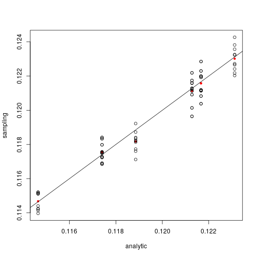

```r
plot(as.vector(analytic), as.vector(mean_sampling), pch=20, col='red',
        ylim=range(unlist(sampling)), xlab='analytic', ylab='sampling')
for (k in 1:length(sampling)) {
    points(as.vector(analytic), as.vector(sampling[[k]]))
}
abline(0,1)
```